# Восстановление золота из руды

Необходимо подготовить прототип модели машинного обучения для компании, которая разрабатывает решения для эффективной работы промышленных предприятий.

Модель должна предсказать коэффициент восстановления золота из золотосодержащей руды. В нашем распоряжении данные с параметрами добычи и очистки.

Модель поможет оптимизировать производство, чтобы не запускать предприятие с убыточными характеристиками.

## Подготовка данных

```python
#загружаем необходимые библиотеки
import pandas as pd
import matplotlib.pyplot as plt
import seaborn as sns
import warnings

from scipy import stats as st

from sklearn.model_selection import RandomizedSearchCV
from sklearn.linear_model import LinearRegression
from sklearn.tree import DecisionTreeRegressor
from sklearn.ensemble import RandomForestRegressor
from sklearn.metrics import make_scorer, mean_absolute_error
from sklearn.preprocessing import StandardScaler
from sklearn.dummy import DummyRegressor

from lightgbm import LGBMRegressor

warnings.filterwarnings('ignore')
```

```python
STATE = 123
```

```python
data = []
try:
    data.append(pd.read_csv('/datasets/gold_recovery_train_new.csv'))
    data.append(pd.read_csv('/datasets/gold_recovery_test_new.csv'))
    data.append(pd.read_csv('/datasets/gold_recovery_full_new.csv'))
except:
    data.append(pd.read_csv('/Users/amirk/Downloads/gold_recovery_train_new.csv'))
    data.append(pd.read_csv('/Users/amirk/Downloads/gold_recovery_test_new.csv'))
    data.append(pd.read_csv('/Users/amirk/Downloads/gold_recovery_full_new.csv'))
```

```python
#функция для изучения основных параметров датасета
def research_data(data):
    print(data.info())
    display(data.head(10))
    print()
    print(data.describe())
```

```python
research_data(data[0])
```

```
<class 'pandas.core.frame.DataFrame'>
RangeIndex: 14149 entries, 0 to 14148
Data columns (total 87 columns):
 #   Column                                              Non-Null Count  Dtype
---  ------                                              --------------  -----
 0   date                                                14149 non-null  object
 1   final.output.concentrate_ag                         14148 non-null  float64
 2   final.output.concentrate_pb                         14148 non-null  float64
 3   final.output.concentrate_sol                        13938 non-null  float64
 4   final.output.concentrate_au                         14149 non-null  float64
 5   final.output.recovery                               14149 non-null  float64
 6   final.output.tail_ag                                14149 non-null  float64
 7   final.output.tail_pb                                14049 non-null  float64
 8   final.output.tail_sol                               14144 non-null  float64
 9   final.output.tail_au                                14149 non-null  float64
```

[output cut: 80 more lines]

|  | date | final.output.concentrate_ag | final.output.concentrate_pb | final.output.concentrate_sol | final.output.concentrate_au | final.output.recovery | final.output.tail_ag | final.output.tail_pb | final.output.tail_sol | final.output.tail_au | ... | secondary_cleaner.state.floatbank4_a_air | secondary_cleaner.state.floatbank4_a_level | secondary_cleaner.state.floatbank4_b_air | secondary_cleaner.state.floatbank4_b_level | secondary_cleaner.state.floatbank5_a_air | secondary_cleaner.state.floatbank5_a_level | secondary_cleaner.state.floatbank5_b_air | secondary_cleaner.state.floatbank5_b_level | secondary_cleaner.state.floatbank6_a_air | secondary_cleaner.state.floatbank6_a_level |
| --- | --- | --- | --- | --- | --- | --- | --- | --- | --- | --- | --- | --- | --- | --- | --- | --- | --- | --- | --- | --- | --- |
| 0 | 2016-01-15 00:00:00 | 6.055403 | 9.889648 | 5.507324 | 42.192020 | 70.541216 | 10.411962 | 0.895447 | 16.904297 | 2.143149 | ... | 14.016835 | -502.488007 | 12.099931 | -504.715942 | 9.925633 | -498.310211 | 8.079666 | -500.470978 | 14.151341 | -605.841980 |
| 1 | 2016-01-15 01:00:00 | 6.029369 | 9.968944 | 5.257781 | 42.701629 | 69.266198 | 10.462676 | 0.927452 | 16.634514 | 2.224930 | ... | 13.992281 | -505.503262 | 11.950531 | -501.331529 | 10.039245 | -500.169983 | 7.984757 | -500.582168 | 13.998353 | -599.787184 |
| 2 | 2016-01-15 02:00:00 | 6.055926 | 10.213995 | 5.383759 | 42.657501 | 68.116445 | 10.507046 | 0.953716 | 16.208849 | 2.257889 | ... | 14.015015 | -502.520901 | 11.912783 | -501.133383 | 10.070913 | -500.129135 | 8.013877 | -500.517572 | 14.028663 | -601.427363 |
| 3 | 2016-01-15 03:00:00 | 6.047977 | 9.977019 | 4.858634 | 42.689819 | 68.347543 | 10.422762 | 0.883763 | 16.532835 | 2.146849 | ... | 14.036510 | -500.857308 | 11.999550 | -501.193686 | 9.970366 | -499.201640 | 7.977324 | -500.255908 | 14.005551 | -599.996129 |
| 4 | 2016-01-15 04:00:00 | 6.148599 | 10.142511 | 4.939416 | 42.774141 | 66.927016 | 10.360302 | 0.792826 | 16.525686 | 2.055292 | ... | 14.027298 | -499.838632 | 11.953070 | -501.053894 | 9.925709 | -501.686727 | 7.894242 | -500.356035 | 13.996647 | -601.496691 |
| 5 | 2016-01-15 05:00:00 | 6.482968 | 10.049416 | 5.480257 | 41.633678 | 69.465816 | 10.182708 | 0.664118 | 16.999638 | 1.918586 | ... | 13.938497 | -500.970168 | 11.883350 | -500.395298 | 10.054147 | -496.374715 | 7.965083 | -499.364752 | 14.017067 | -599.707915 |
| 6 | 2016-01-15 06:00:00 | 6.533849 | 10.058141 | 4.569100 | 41.995316 | 69.300835 | 10.304598 | 0.807342 | 16.723575 | 2.058913 | ... | 14.046819 | -500.971133 | 12.091543 | -500.501426 | 10.003247 | -497.083180 | 8.010890 | -500.002423 | 14.029649 | -600.905470 |
| 7 | 2016-01-15 07:00:00 | 6.130823 | 9.935481 | 4.389813 | 42.452727 | 70.230976 | 10.443288 | 0.949346 | 16.689959 | 2.143437 | ... | 13.974691 | -501.819696 | 12.101324 | -500.583446 | 9.873169 | -499.171928 | 7.993381 | -499.794518 | 13.984498 | -600.411070 |
| 8 | 2016-01-15 08:00:00 | 5.834140 | 10.071156 | 4.876389 | 43.404078 | 69.688595 | 10.420140 | 1.065453 | 17.201948 | 2.209881 | ... | 13.964030 | -504.252450 | 12.060738 | -501.174549 | 10.033838 | -501.178133 | 7.881604 | -499.729434 | 13.967135 | -599.061188 |
| 9 | 2016-01-15 09:00:00 | 5.687063 | 9.980404 | 5.282514 | 43.235220 | 70.279619 | 10.487013 | 1.159805 | 17.483979 | 2.209593 | ... | 13.989632 | -503.195299 | 12.052233 | -500.928547 | 9.962574 | -502.986357 | 7.979219 | -500.146835 | 13.981614 | -598.070855 |

10 rows × 87 columns

```
       final.output.concentrate_ag  final.output.concentrate_pb  \
count                 14148.000000                 14148.000000
mean                      5.142034                    10.132960
std                       1.369586                     1.654930
min                       0.000000                     0.000000
25%                       4.211620                     9.297355
50%                       4.994652                    10.297144
75%                       5.859540                    11.170603
max                      16.001945                    17.031899

       final.output.concentrate_sol  final.output.concentrate_au  \
count                  13938.000000                 14149.000000
mean                       9.202849                    44.003792
std                        2.790516                     4.905261
min                        0.000000                     0.000000
25%                        7.484645                    43.276111
50%                        8.845462                    44.872436
75%                       10.487508                    46.166425
max                       18.124851                    52.756638

       final.output.recovery  final.output.tail_ag  final.output.tail_pb  \
count           14149.000000          14149.000000          14049.000000
mean               66.518832              9.607035              2.597298
std                10.295402              2.319069              0.971843
min                 0.000000              0.000000              0.000000
25%                62.545817              7.997429              1.905973
50%                67.432775              9.480270              2.592022
75%                72.346428             11.003707              3.241723
max               100.000000             19.552149              5.639565

       final.output.tail_sol  final.output.tail_au  \
count           14144.000000          14149.000000
mean               10.512122              2.918421
std                 3.003617              0.903712
min                 0.000000              0.000000
25%                 8.811324              2.368607
50%                10.514621              2.851025
75%                11.933009              3.434764
max                22.317730              8.197408

```

[output cut: 96 more lines]

```
50%                                   19.984175
75%                                   24.991623
max                                   32.188906

       secondary_cleaner.state.floatbank6_a_level
count                                14148.000000
mean                                  -506.798480
std                                     37.079249
min                                   -809.398668
25%                                   -500.745104
50%                                   -500.061431
75%                                   -499.536466
max                                   -104.427459

[8 rows x 86 columns]
```

```python
research_data(data[1])
```

```
<class 'pandas.core.frame.DataFrame'>
RangeIndex: 5290 entries, 0 to 5289
Data columns (total 53 columns):
 #   Column                                      Non-Null Count  Dtype
---  ------                                      --------------  -----
 0   date                                        5290 non-null   object
 1   primary_cleaner.input.sulfate               5286 non-null   float64
 2   primary_cleaner.input.depressant            5285 non-null   float64
 3   primary_cleaner.input.feed_size             5290 non-null   float64
 4   primary_cleaner.input.xanthate              5286 non-null   float64
 5   primary_cleaner.state.floatbank8_a_air      5290 non-null   float64
 6   primary_cleaner.state.floatbank8_a_level    5290 non-null   float64
 7   primary_cleaner.state.floatbank8_b_air      5290 non-null   float64
 8   primary_cleaner.state.floatbank8_b_level    5290 non-null   float64
 9   primary_cleaner.state.floatbank8_c_air      5290 non-null   float64
```

[output cut: 46 more lines]

|  | date | primary_cleaner.input.sulfate | primary_cleaner.input.depressant | primary_cleaner.input.feed_size | primary_cleaner.input.xanthate | primary_cleaner.state.floatbank8_a_air | primary_cleaner.state.floatbank8_a_level | primary_cleaner.state.floatbank8_b_air | primary_cleaner.state.floatbank8_b_level | primary_cleaner.state.floatbank8_c_air | ... | secondary_cleaner.state.floatbank4_a_air | secondary_cleaner.state.floatbank4_a_level | secondary_cleaner.state.floatbank4_b_air | secondary_cleaner.state.floatbank4_b_level | secondary_cleaner.state.floatbank5_a_air | secondary_cleaner.state.floatbank5_a_level | secondary_cleaner.state.floatbank5_b_air | secondary_cleaner.state.floatbank5_b_level | secondary_cleaner.state.floatbank6_a_air | secondary_cleaner.state.floatbank6_a_level |
| --- | --- | --- | --- | --- | --- | --- | --- | --- | --- | --- | --- | --- | --- | --- | --- | --- | --- | --- | --- | --- | --- |
| 0 | 2016-09-01 00:59:59 | 210.800909 | 14.993118 | 8.080000 | 1.005021 | 1398.981301 | -500.225577 | 1399.144926 | -499.919735 | 1400.102998 | ... | 12.023554 | -497.795834 | 8.016656 | -501.289139 | 7.946562 | -432.317850 | 4.872511 | -500.037437 | 26.705889 | -499.709414 |
| 1 | 2016-09-01 01:59:59 | 215.392455 | 14.987471 | 8.080000 | 0.990469 | 1398.777912 | -500.057435 | 1398.055362 | -499.778182 | 1396.151033 | ... | 12.058140 | -498.695773 | 8.130979 | -499.634209 | 7.958270 | -525.839648 | 4.878850 | -500.162375 | 25.019940 | -499.819438 |
| 2 | 2016-09-01 02:59:59 | 215.259946 | 12.884934 | 7.786667 | 0.996043 | 1398.493666 | -500.868360 | 1398.860436 | -499.764529 | 1398.075709 | ... | 11.962366 | -498.767484 | 8.096893 | -500.827423 | 8.071056 | -500.801673 | 4.905125 | -499.828510 | 24.994862 | -500.622559 |
| 3 | 2016-09-01 03:59:59 | 215.336236 | 12.006805 | 7.640000 | 0.863514 | 1399.618111 | -498.863574 | 1397.440120 | -499.211024 | 1400.129303 | ... | 12.033091 | -498.350935 | 8.074946 | -499.474407 | 7.897085 | -500.868509 | 4.931400 | -499.963623 | 24.948919 | -498.709987 |
| 4 | 2016-09-01 04:59:59 | 199.099327 | 10.682530 | 7.530000 | 0.805575 | 1401.268123 | -500.808305 | 1398.128818 | -499.504543 | 1402.172226 | ... | 12.025367 | -500.786497 | 8.054678 | -500.397500 | 8.107890 | -509.526725 | 4.957674 | -500.360026 | 25.003331 | -500.856333 |
| 5 | 2016-09-01 05:59:59 | 168.485085 | 8.817007 | 7.420000 | 0.791191 | 1402.826803 | -499.299521 | 1401.511119 | -499.205357 | 1404.088107 | ... | 12.029797 | -499.814895 | 8.036586 | -500.371492 | 8.041446 | -510.037054 | 4.983949 | -499.990990 | 24.978973 | -500.475640 |
| 6 | 2016-09-01 06:59:59 | 144.133440 | 7.924610 | 7.420000 | 0.788838 | 1398.252401 | -499.748672 | 1393.255503 | -499.195380 | 1396.738566 | ... | 12.026296 | -499.473127 | 8.027984 | -500.983079 | 7.907340 | -507.964971 | 5.010224 | -500.043697 | 25.040709 | -499.501984 |
| 7 | 2016-09-01 07:59:59 | 133.513396 | 8.055252 | 6.988000 | 0.801871 | 1401.669677 | -501.777839 | 1400.754446 | -502.514024 | 1400.465244 | ... | 12.040911 | -501.293852 | 8.020490 | -499.185229 | 8.116897 | -511.927561 | 5.036498 | -500.149615 | 25.032580 | -503.970657 |
| 8 | 2016-09-01 08:59:59 | 133.735356 | 7.999618 | 6.935000 | 0.789329 | 1402.358981 | -499.981597 | 1400.985954 | -496.802968 | 1401.168584 | ... | 11.998184 | -499.481608 | 8.012610 | -500.896783 | 7.974422 | -521.199104 | 5.061599 | -499.791519 | 25.005063 | -497.613716 |
| 9 | 2016-09-01 09:59:59 | 126.961069 | 8.017856 | 7.030000 | 0.805298 | 1400.816120 | -499.014158 | 1399.975401 | -499.570552 | 1401.871924 | ... | 12.040725 | -499.987743 | 7.989503 | -499.750625 | 7.989710 | -509.946737 | 5.068811 | -499.293900 | 24.992741 | -499.272255 |

10 rows × 53 columns

```
       primary_cleaner.input.sulfate  primary_cleaner.input.depressant  \
count                    5286.000000                       5285.000000
mean                      174.839652                          8.683596
std                        43.027080                          3.072050
min                         2.566156                          0.003839
25%                       147.121401                          6.489555
50%                       177.828489                          8.052207
75%                       208.125438                         10.027764
max                       265.983123                         40.000000

       primary_cleaner.input.feed_size  primary_cleaner.input.xanthate  \
count                      5290.000000                     5286.000000
mean                          7.266339                        1.383803
std                           0.610219                        0.643474
min                           5.650000                        0.004984
25%                           6.890000                        0.907623
50%                           7.250000                        1.197610
75%                           7.600000                        1.797819
max                          15.500000                        4.102454

       primary_cleaner.state.floatbank8_a_air  \
count                            5.290000e+03
mean                             1.539494e+03
std                              1.167979e+02
min                              5.445860e-32
25%                              1.498936e+03
50%                              1.585129e+03
75%                              1.602077e+03
max                              2.103104e+03

       primary_cleaner.state.floatbank8_a_level  \
count                               5290.000000
mean                                -497.665883
std                                   19.952431
min                                 -795.316337
25%                                 -500.357298
50%                                 -499.969164
75%                                 -499.568951
max                                  -57.195404

```

[output cut: 126 more lines]

```
50%                                   16.014935
75%                                   21.020013
max                                   26.705889

       secondary_cleaner.state.floatbank6_a_level
count                                 5290.000000
mean                                  -501.793193
std                                     39.044215
min                                   -809.741464
25%                                   -500.690984
50%                                   -500.007126
75%                                   -499.373018
max                                   -123.307487

[8 rows x 52 columns]
```

```python
research_data(data[2])
```

```
<class 'pandas.core.frame.DataFrame'>
RangeIndex: 19439 entries, 0 to 19438
Data columns (total 87 columns):
 #   Column                                              Non-Null Count  Dtype
---  ------                                              --------------  -----
 0   date                                                19439 non-null  object
 1   final.output.concentrate_ag                         19438 non-null  float64
 2   final.output.concentrate_pb                         19438 non-null  float64
 3   final.output.concentrate_sol                        19228 non-null  float64
 4   final.output.concentrate_au                         19439 non-null  float64
 5   final.output.recovery                               19439 non-null  float64
 6   final.output.tail_ag                                19438 non-null  float64
 7   final.output.tail_pb                                19338 non-null  float64
 8   final.output.tail_sol                               19433 non-null  float64
 9   final.output.tail_au                                19439 non-null  float64
```

[output cut: 80 more lines]

|  | date | final.output.concentrate_ag | final.output.concentrate_pb | final.output.concentrate_sol | final.output.concentrate_au | final.output.recovery | final.output.tail_ag | final.output.tail_pb | final.output.tail_sol | final.output.tail_au | ... | secondary_cleaner.state.floatbank4_a_air | secondary_cleaner.state.floatbank4_a_level | secondary_cleaner.state.floatbank4_b_air | secondary_cleaner.state.floatbank4_b_level | secondary_cleaner.state.floatbank5_a_air | secondary_cleaner.state.floatbank5_a_level | secondary_cleaner.state.floatbank5_b_air | secondary_cleaner.state.floatbank5_b_level | secondary_cleaner.state.floatbank6_a_air | secondary_cleaner.state.floatbank6_a_level |
| --- | --- | --- | --- | --- | --- | --- | --- | --- | --- | --- | --- | --- | --- | --- | --- | --- | --- | --- | --- | --- | --- |
| 0 | 2016-01-15 00:00:00 | 6.055403 | 9.889648 | 5.507324 | 42.192020 | 70.541216 | 10.411962 | 0.895447 | 16.904297 | 2.143149 | ... | 14.016835 | -502.488007 | 12.099931 | -504.715942 | 9.925633 | -498.310211 | 8.079666 | -500.470978 | 14.151341 | -605.841980 |
| 1 | 2016-01-15 01:00:00 | 6.029369 | 9.968944 | 5.257781 | 42.701629 | 69.266198 | 10.462676 | 0.927452 | 16.634514 | 2.224930 | ... | 13.992281 | -505.503262 | 11.950531 | -501.331529 | 10.039245 | -500.169983 | 7.984757 | -500.582168 | 13.998353 | -599.787184 |
| 2 | 2016-01-15 02:00:00 | 6.055926 | 10.213995 | 5.383759 | 42.657501 | 68.116445 | 10.507046 | 0.953716 | 16.208849 | 2.257889 | ... | 14.015015 | -502.520901 | 11.912783 | -501.133383 | 10.070913 | -500.129135 | 8.013877 | -500.517572 | 14.028663 | -601.427363 |
| 3 | 2016-01-15 03:00:00 | 6.047977 | 9.977019 | 4.858634 | 42.689819 | 68.347543 | 10.422762 | 0.883763 | 16.532835 | 2.146849 | ... | 14.036510 | -500.857308 | 11.999550 | -501.193686 | 9.970366 | -499.201640 | 7.977324 | -500.255908 | 14.005551 | -599.996129 |
| 4 | 2016-01-15 04:00:00 | 6.148599 | 10.142511 | 4.939416 | 42.774141 | 66.927016 | 10.360302 | 0.792826 | 16.525686 | 2.055292 | ... | 14.027298 | -499.838632 | 11.953070 | -501.053894 | 9.925709 | -501.686727 | 7.894242 | -500.356035 | 13.996647 | -601.496691 |
| 5 | 2016-01-15 05:00:00 | 6.482968 | 10.049416 | 5.480257 | 41.633678 | 69.465816 | 10.182708 | 0.664118 | 16.999638 | 1.918586 | ... | 13.938497 | -500.970168 | 11.883350 | -500.395298 | 10.054147 | -496.374715 | 7.965083 | -499.364752 | 14.017067 | -599.707915 |
| 6 | 2016-01-15 06:00:00 | 6.533849 | 10.058141 | 4.569100 | 41.995316 | 69.300835 | 10.304598 | 0.807342 | 16.723575 | 2.058913 | ... | 14.046819 | -500.971133 | 12.091543 | -500.501426 | 10.003247 | -497.083180 | 8.010890 | -500.002423 | 14.029649 | -600.905470 |
| 7 | 2016-01-15 07:00:00 | 6.130823 | 9.935481 | 4.389813 | 42.452727 | 70.230976 | 10.443288 | 0.949346 | 16.689959 | 2.143437 | ... | 13.974691 | -501.819696 | 12.101324 | -500.583446 | 9.873169 | -499.171928 | 7.993381 | -499.794518 | 13.984498 | -600.411070 |
| 8 | 2016-01-15 08:00:00 | 5.834140 | 10.071156 | 4.876389 | 43.404078 | 69.688595 | 10.420140 | 1.065453 | 17.201948 | 2.209881 | ... | 13.964030 | -504.252450 | 12.060738 | -501.174549 | 10.033838 | -501.178133 | 7.881604 | -499.729434 | 13.967135 | -599.061188 |
| 9 | 2016-01-15 09:00:00 | 5.687063 | 9.980404 | 5.282514 | 43.235220 | 70.279619 | 10.487013 | 1.159805 | 17.483979 | 2.209593 | ... | 13.989632 | -503.195299 | 12.052233 | -500.928547 | 9.962574 | -502.986357 | 7.979219 | -500.146835 | 13.981614 | -598.070855 |

10 rows × 87 columns

```
       final.output.concentrate_ag  final.output.concentrate_pb  \
count                 19438.000000                 19438.000000
mean                      5.168470                     9.978895
std                       1.372348                     1.669240
min                       0.000000                     0.000000
25%                       4.251240                     9.137262
50%                       5.066094                    10.102433
75%                       5.895527                    11.035769
max                      16.001945                    17.031899

       final.output.concentrate_sol  final.output.concentrate_au  \
count                  19228.000000                 19439.000000
mean                       9.501224                    44.076513
std                        2.787537                     5.129784
min                        0.000000                     0.000000
25%                        7.722820                    43.402215
50%                        9.218961                    45.011244
75%                       10.947813                    46.275313
max                       19.615720                    52.756638

       final.output.recovery  final.output.tail_ag  final.output.tail_pb  \
count           19439.000000          19438.000000          19338.000000
mean               67.050208              9.688589              2.705795
std                10.125840              2.328642              0.949077
min                 0.000000              0.000000              0.000000
25%                63.299712              8.062878              2.040119
50%                68.172738              9.743623              2.748730
75%                72.686642             11.134294              3.333216
max               100.000000             19.552149              5.804178

       final.output.tail_sol  final.output.tail_au  \
count           19433.000000          19439.000000
mean               10.583728              3.042467
std                 2.868782              0.922808
min                 0.000000              0.000000
25%                 8.938947              2.461138
50%                10.622456              2.984909
75%                12.104271              3.571351
max                22.317730              8.245022

```

[output cut: 96 more lines]

```
50%                                   19.960541
75%                                   24.003170
max                                   32.188906

       secondary_cleaner.state.floatbank6_a_level
count                                19438.000000
mean                                  -505.436305
std                                     37.689057
min                                   -809.741464
25%                                   -500.728067
50%                                   -500.048400
75%                                   -499.495378
max                                   -104.427459

[8 rows x 86 columns]
```

### Промежуточные выводы:

- в датасете `gold_recovery_train_new` представлено 87 признаков, описывающих процесс восстановления золота из руды. Столбец **data** имеет тип данных **object**, нужно заменить на **datetime**. В некоторых столбцах присутсвуют пропуски. Попробуем заполнить их данными из датасета `gold_recovery_full_new`, если пропуски останутся заполним их медианными значениями.
- в датасете `gold_recovery_test_new` представлено 53 признака, причем нет целевых признаков, необходимых для расчета **SMAPE**, это **rougher.output.recovery** и **final.output.recovery**. В столбце **date** также изменим тип данных. Пропуски постараемся заполнить аналогичным образом. В некоторых столбцах присутсвуют пропуски. Попробуем заполнить их данными из датасета `gold_recovery_full_new`, если пропуски останутся заполним их медианными значениями.
- в датасете `gold_recovery_full_new` представлено также 87 признаков. В столбце **date** изменим тип данных.

Внесем все необходимые изменения на этапе предобработки данных.

### Проверим правильность расчета эффективности обогащения

- вычислим эффективность обогащения на обучающей выборке для признака rougher.output.recovery
- найдем MAE между своими расчётами и значением признака

```python
def recovery_calc(c, f, t):
    recovery = c * (f - t) / (f * (c - t)) * 100
    return recovery
```

```python
tempt_table = pd.DataFrame()
tempt_table['rougher.output.recovery'] = data[0]['rougher.output.recovery']
tempt_table['rougher.output.recovery_my'] = recovery_calc(data[0]['rougher.output.concentrate_au'],
                                                          data[0]['rougher.input.feed_au'],
                                                          data[0]['rougher.output.tail_au'])
tempt_table['mae'] = mean_absolute_error(tempt_table['rougher.output.recovery'], tempt_table['rougher.output.recovery_my'])
tempt_table
```

|  | rougher.output.recovery | rougher.output.recovery_my | mae |
| --- | --- | --- | --- |
| 0 | 87.107763 | 87.107763 | 9.735123e-15 |
| 1 | 86.843261 | 86.843261 | 9.735123e-15 |
| 2 | 86.842308 | 86.842308 | 9.735123e-15 |
| 3 | 87.226430 | 87.226430 | 9.735123e-15 |
| 4 | 86.688794 | 86.688794 | 9.735123e-15 |
| ... | ... | ... | ... |
| 14144 | 89.574376 | 89.574376 | 9.735123e-15 |
| 14145 | 87.724007 | 87.724007 | 9.735123e-15 |
| 14146 | 88.890579 | 88.890579 | 9.735123e-15 |
| 14147 | 89.858126 | 89.858126 | 9.735123e-15 |
| 14148 | 89.514960 | 89.514960 | 9.735123e-15 |

14149 rows × 3 columns

Эффективность обогащения рассчитана правильно, MAE приближается к 0.

### Проанализируем признаки, недоступные в тестовой выборке.

```python
#найдем признаки недоступные в тестовой выборке
not_av_features = data[0].drop(data[1].columns, axis=1)
not_av_features.info()
```

```
<class 'pandas.core.frame.DataFrame'>
RangeIndex: 14149 entries, 0 to 14148
Data columns (total 34 columns):
 #   Column                                              Non-Null Count  Dtype
---  ------                                              --------------  -----
 0   final.output.concentrate_ag                         14148 non-null  float64
 1   final.output.concentrate_pb                         14148 non-null  float64
 2   final.output.concentrate_sol                        13938 non-null  float64
 3   final.output.concentrate_au                         14149 non-null  float64
 4   final.output.recovery                               14149 non-null  float64
 5   final.output.tail_ag                                14149 non-null  float64
 6   final.output.tail_pb                                14049 non-null  float64
 7   final.output.tail_sol                               14144 non-null  float64
 8   final.output.tail_au                                14149 non-null  float64
 9   primary_cleaner.output.concentrate_ag               14149 non-null  float64
```

[output cut: 26 more lines]

В тестовой выборке недостуны признаки, которые рассчитываются в процессе восстановления золота из руды. Это концентрации различных примесей до определенного этапа обработки, после данного этапа, их соотношения, тип всех данных **float**.

Необходимо уточнить у заказчика, будут ли нам доступны данные показатели при прогнозировании эффективности обогащения. Исходя из условий задания, для нас будут доступны только показатели из тестовой выборки, поэтому при создании моделей будем использовать только указанные показатели.  
Из обучающего датасета удалим недоступные в тестовой выборке признаки.

### Предобработка данных

```python
# добавим целевые признаки в тестовый датасет
data[1] = data[1].merge(data[2][['date', 'rougher.output.recovery', 'final.output.recovery']], how='left', on='date')
```

```python
data[1].info()
```

```
<class 'pandas.core.frame.DataFrame'>
Int64Index: 5290 entries, 0 to 5289
Data columns (total 55 columns):
 #   Column                                      Non-Null Count  Dtype
---  ------                                      --------------  -----
 0   date                                        5290 non-null   object
 1   primary_cleaner.input.sulfate               5286 non-null   float64
 2   primary_cleaner.input.depressant            5285 non-null   float64
 3   primary_cleaner.input.feed_size             5290 non-null   float64
 4   primary_cleaner.input.xanthate              5286 non-null   float64
 5   primary_cleaner.state.floatbank8_a_air      5290 non-null   float64
 6   primary_cleaner.state.floatbank8_a_level    5290 non-null   float64
 7   primary_cleaner.state.floatbank8_b_air      5290 non-null   float64
 8   primary_cleaner.state.floatbank8_b_level    5290 non-null   float64
 9   primary_cleaner.state.floatbank8_c_air      5290 non-null   float64
```

[output cut: 47 more lines]

```python
# удалим из тренировочного датасета параметры, которых нет в тестовой выборке
data[0] = data[0].drop(data[0].drop(data[1].columns, axis=1).columns, axis=1)
```

```python
data[0].info()
```

```
<class 'pandas.core.frame.DataFrame'>
RangeIndex: 14149 entries, 0 to 14148
Data columns (total 55 columns):
 #   Column                                      Non-Null Count  Dtype
---  ------                                      --------------  -----
 0   date                                        14149 non-null  object
 1   final.output.recovery                       14149 non-null  float64
 2   primary_cleaner.input.sulfate               14129 non-null  float64
 3   primary_cleaner.input.depressant            14117 non-null  float64
 4   primary_cleaner.input.feed_size             14149 non-null  float64
 5   primary_cleaner.input.xanthate              14049 non-null  float64
 6   primary_cleaner.state.floatbank8_a_air      14145 non-null  float64
 7   primary_cleaner.state.floatbank8_a_level    14148 non-null  float64
 8   primary_cleaner.state.floatbank8_b_air      14145 non-null  float64
 9   primary_cleaner.state.floatbank8_b_level    14148 non-null  float64
```

[output cut: 47 more lines]

```python
# напишем функцию для замены типа данных в столбце date
def transform_date(data):
    data['date'] = pd.to_datetime(data['date'], format='%Y%m%dT%H:%M:%S')
```

```python
#заменим формат в столбце date
for i in data:
    transform_date(i)
```

```python
#функция для заполнения пропусков данными из датафрейма gold_recovery_full_new
def fill_nan(data_nan, data_full):
    data_x = data_nan.isna().sum() #для лучшей читаемости кода сделаю в несколько строк
    data_x = data_x.loc[data_x[:,] > 0]
    data_nan[data_x.index] = data_nan[data_x.index].fillna(data_full[data_x.index])
    return data_nan
```

```python
data[0] = fill_nan(data[0], data[2])
```

```python
data[0].isna().sum().sort_values()
```

```
date                                            0
final.output.recovery                           0
rougher.state.floatbank10_d_air                 0
rougher.output.recovery                         0
primary_cleaner.input.feed_size                 0
rougher.state.floatbank10_d_level               0
rougher.state.floatbank10_e_air                 0
rougher.state.floatbank10_e_level               0
rougher.state.floatbank10_f_air                 0
rougher.input.feed_au                           0
rougher.state.floatbank10_f_level               0
rougher.input.feed_ag                           0
secondary_cleaner.state.floatbank2_a_air        1
secondary_cleaner.state.floatbank2_a_level      1
secondary_cleaner.state.floatbank2_b_level      1
secondary_cleaner.state.floatbank3_a_level      1
secondary_cleaner.state.floatbank3_b_air        1
secondary_cleaner.state.floatbank3_b_level      1
secondary_cleaner.state.floatbank4_a_air        1
secondary_cleaner.state.floatbank4_a_level      1
secondary_cleaner.state.floatbank4_b_air        1
secondary_cleaner.state.floatbank4_b_level      1
secondary_cleaner.state.floatbank5_a_air        1
secondary_cleaner.state.floatbank5_a_level      1
secondary_cleaner.state.floatbank5_b_air        1
secondary_cleaner.state.floatbank5_b_level      1
rougher.state.floatbank10_c_level               1
rougher.state.floatbank10_c_air                 1
rougher.state.floatbank10_b_air                 1
secondary_cleaner.state.floatbank6_a_air        1
primary_cleaner.state.floatbank8_a_air          1
primary_cleaner.state.floatbank8_a_level        1
primary_cleaner.state.floatbank8_b_air          1
primary_cleaner.state.floatbank8_b_level        1
primary_cleaner.state.floatbank8_c_air          1
primary_cleaner.state.floatbank8_c_level        1
primary_cleaner.state.floatbank8_d_level        1
rougher.state.floatbank10_b_level               1
secondary_cleaner.state.floatbank6_a_level      1
rougher.input.floatbank10_xanthate              1
rougher.state.floatbank10_a_air                 1
rougher.state.floatbank10_a_level               1
rougher.input.feed_rate                         1
primary_cleaner.state.floatbank8_d_air          2
rougher.input.floatbank10_sulfate               3
secondary_cleaner.state.floatbank2_b_air        4
primary_cleaner.input.sulfate                   4
secondary_cleaner.state.floatbank3_a_air        4
rougher.input.floatbank11_sulfate               5
primary_cleaner.input.xanthate                  8
primary_cleaner.input.depressant                9
rougher.input.feed_pb                          11
rougher.input.feed_sol                         32
rougher.input.floatbank11_xanthate             38
rougher.input.feed_size                       136
dtype: int64
```

```python
data[1] = fill_nan(data[1], data[2])
```

```python
data[1].isna().sum().sort_values()
```

```
date                                          0
rougher.state.floatbank10_d_air               0
rougher.state.floatbank10_d_level             0
rougher.state.floatbank10_e_air               0
rougher.state.floatbank10_e_level             0
rougher.state.floatbank10_f_air               0
rougher.state.floatbank10_f_level             0
secondary_cleaner.state.floatbank2_a_air      0
secondary_cleaner.state.floatbank2_a_level    0
secondary_cleaner.state.floatbank2_b_air      0
secondary_cleaner.state.floatbank2_b_level    0
secondary_cleaner.state.floatbank3_a_air      0
rougher.state.floatbank10_c_level             0
secondary_cleaner.state.floatbank3_a_level    0
secondary_cleaner.state.floatbank3_b_level    0
secondary_cleaner.state.floatbank4_a_air      0
secondary_cleaner.state.floatbank4_a_level    0
secondary_cleaner.state.floatbank4_b_air      0
secondary_cleaner.state.floatbank4_b_level    0
secondary_cleaner.state.floatbank5_a_air      0
secondary_cleaner.state.floatbank5_a_level    0
secondary_cleaner.state.floatbank5_b_air      0
secondary_cleaner.state.floatbank5_b_level    0
secondary_cleaner.state.floatbank6_a_air      0
secondary_cleaner.state.floatbank6_a_level    0
secondary_cleaner.state.floatbank3_b_air      0
rougher.output.recovery                       0
rougher.state.floatbank10_c_air               0
rougher.state.floatbank10_b_air               0
primary_cleaner.input.sulfate                 0
primary_cleaner.input.depressant              0
primary_cleaner.input.feed_size               0
primary_cleaner.input.xanthate                0
primary_cleaner.state.floatbank8_a_air        0
primary_cleaner.state.floatbank8_a_level      0
primary_cleaner.state.floatbank8_b_air        0
primary_cleaner.state.floatbank8_b_level      0
primary_cleaner.state.floatbank8_c_air        0
primary_cleaner.state.floatbank8_c_level      0
primary_cleaner.state.floatbank8_d_air        0
rougher.state.floatbank10_b_level             0
primary_cleaner.state.floatbank8_d_level      0
rougher.input.feed_pb                         0
rougher.input.feed_rate                       0
rougher.input.feed_size                       0
rougher.input.feed_sol                        0
rougher.input.feed_au                         0
rougher.input.floatbank10_sulfate             0
rougher.input.floatbank10_xanthate            0
rougher.input.floatbank11_sulfate             0
rougher.state.floatbank10_a_air               0
rougher.state.floatbank10_a_level             0
rougher.input.feed_ag                         0
final.output.recovery                         0
rougher.input.floatbank11_xanthate            1
dtype: int64
```

```python
def time_columns(data):
    data['day'] = data['date'].dt.day
    data['month'] = data['date'].dt.month
    data['year'] = data['date'].dt.year
```

```python
time_columns(data[0])
```

```python
time_columns(data[1])
```

```python
time_columns(data[2])
```

```python
# функция для заполнения пропусков медианой
def fill_nan_by_time(data):
    data_nan = data.isna().sum() #найдем названия колонок с пропусками
    nan_columns = data_nan.loc[data_nan[:,] > 0].index
    #для колонок с пропусками найдем медианы, добавим эту колонку в датафрейм, заполним пропуски и удалим столбец с медианой
    for i in nan_columns:
        median_feature = data.groupby(by=['year', 'month', 'day'])[i].median()
        median_feature.name = ('nan_feature')
        data = data.merge(median_feature, how='left', on=['year', 'month', 'day'])
        data[i] = data[i].fillna(data['nan_feature'])
        data = data.drop('nan_feature', axis=1)
        #если в колонке остались пропуски дозаполним их медианой за месяц
        if data[i].isna().sum() > 0:
            median_feature = data.groupby(by=['year', 'month'])[i].median()
            median_feature.name = ('nan_feature')
            data = data.merge(median_feature, how='left', on=['year', 'month'])
            data[i] = data[i].fillna(data['nan_feature'])
            data = data.drop('nan_feature', axis=1)
    data = data.drop(['year', 'month', 'day'], axis=1)
    return data
```

```python
data[0] = fill_nan_by_time(data[0])
```

```python
data[0].info()
```

```
<class 'pandas.core.frame.DataFrame'>
Int64Index: 14149 entries, 0 to 14148
Data columns (total 55 columns):
 #   Column                                      Non-Null Count  Dtype
---  ------                                      --------------  -----
 0   date                                        14149 non-null  datetime64[ns]
 1   final.output.recovery                       14149 non-null  float64
 2   primary_cleaner.input.sulfate               14149 non-null  float64
 3   primary_cleaner.input.depressant            14149 non-null  float64
 4   primary_cleaner.input.feed_size             14149 non-null  float64
 5   primary_cleaner.input.xanthate              14149 non-null  float64
 6   primary_cleaner.state.floatbank8_a_air      14149 non-null  float64
 7   primary_cleaner.state.floatbank8_a_level    14149 non-null  float64
 8   primary_cleaner.state.floatbank8_b_air      14149 non-null  float64
 9   primary_cleaner.state.floatbank8_b_level    14149 non-null  float64
```

[output cut: 47 more lines]

```python
data[1] = fill_nan_by_time(data[1])
```

```python
data[1].info()
```

```
<class 'pandas.core.frame.DataFrame'>
Int64Index: 5290 entries, 0 to 5289
Data columns (total 55 columns):
 #   Column                                      Non-Null Count  Dtype
---  ------                                      --------------  -----
 0   date                                        5290 non-null   datetime64[ns]
 1   primary_cleaner.input.sulfate               5290 non-null   float64
 2   primary_cleaner.input.depressant            5290 non-null   float64
 3   primary_cleaner.input.feed_size             5290 non-null   float64
 4   primary_cleaner.input.xanthate              5290 non-null   float64
 5   primary_cleaner.state.floatbank8_a_air      5290 non-null   float64
 6   primary_cleaner.state.floatbank8_a_level    5290 non-null   float64
 7   primary_cleaner.state.floatbank8_b_air      5290 non-null   float64
 8   primary_cleaner.state.floatbank8_b_level    5290 non-null   float64
 9   primary_cleaner.state.floatbank8_c_air      5290 non-null   float64
```

[output cut: 47 more lines]

Все пропуски заполнены! Данные готовы для дальнейшей работы!

## Анализ данных

### Оценим, как меняется концентрация металлов (Au, Ag, Pb) на различных этапах очистки.

Оценка будет проведена на полном датасете.

```python
METALS = ['au', 'ag', 'pb']
STAGES = ['rougher.input.feed_',
          'rougher.output.concentrate_',
          'primary_cleaner.output.concentrate_',
          'final.output.concentrate_']
STAGES_RUS = ['До очистки', 'После флотации', 'После 1 этапа очистки', 'После 2 этапа очистки']
```

```python
#функция для оценки концентрации металлов на разных этапах
def metal_concentration(data):
    for i in METALS:
        table = pd.DataFrame()
        for j in range(len(STAGES)):
            table[STAGES_RUS[j]] = data[STAGES[j] + i]
        print(f'Данные по металлу {i.title()}')
        display(table.head())
        print(table.describe())
        plt.figure(figsize=(10, 4))
        sns.boxplot(data=table)
        plt.xlabel('Этапы очистки')
        plt.ylabel(f'Концентрация {i.title()} (%)')
        plt.title(f'Концентрация {i.title()} на различных этапах очистки')
        plt.show()
        print()
```

```
Данные по металлу Au
```

|  | До очистки | После флотации | После 1 этапа очистки | После 2 этапа очистки |
| --- | --- | --- | --- | --- |
| 0 | 6.486150 | 19.793808 | 34.174427 | 42.192020 |
| 1 | 6.478583 | 20.050975 | 34.118526 | 42.701629 |
| 2 | 6.362222 | 19.737170 | 33.969464 | 42.657501 |
| 3 | 6.118189 | 19.320810 | 28.260743 | 42.689819 |
| 4 | 5.663707 | 19.216101 | 33.044932 | 42.774141 |

```
         До очистки  После флотации  После 1 этапа очистки  \
count  19439.000000    19439.000000           19439.000000
mean       8.266097       19.772000              32.119400
std        1.955092        3.753600               5.627611
min        0.010000        0.000000               0.000000
25%        6.854384       18.802523              30.463140
50%        8.125839       20.280214              32.841295
75%        9.769917       21.717843              35.048006
max       13.731330       28.824507              45.933934

       После 2 этапа очистки
count           19439.000000
mean               44.076513
std                 5.129784
min                 0.000000
25%                43.402215
50%                45.011244
75%                46.275313
max                52.756638
```

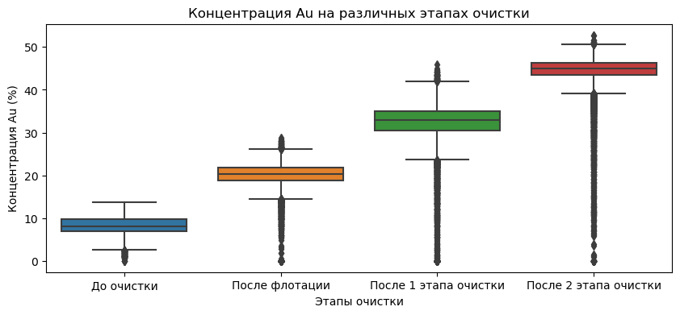

```
Данные по металлу Ag
```

|  | До очистки | После флотации | После 1 этапа очистки | После 2 этапа очистки |
| --- | --- | --- | --- | --- |
| 0 | 6.100378 | 11.500771 | 8.547551 | 6.055403 |
| 1 | 6.161113 | 11.615865 | 8.558743 | 6.029369 |
| 2 | 6.116455 | 11.695753 | 8.603505 | 6.055926 |
| 3 | 6.043309 | 11.915047 | 7.221879 | 6.047977 |
| 4 | 6.060915 | 12.411054 | 9.089428 | 6.148599 |

```
         До очистки  После флотации  После 1 этапа очистки  \
count  19439.000000    19439.000000           19439.000000
mean       8.794927       11.994759               8.442408
std        1.936847        2.733862               2.054465
min        0.010000        0.000000               0.000000
25%        7.237967       10.628337               7.263288
50%        8.593574       12.098115               8.507298
75%       10.213771       13.736996               9.809001
max       14.596026       24.480271              16.081632

       После 2 этапа очистки
count           19438.000000
mean                5.168470
std                 1.372348
min                 0.000000
25%                 4.251240
50%                 5.066094
75%                 5.895527
max                16.001945
```

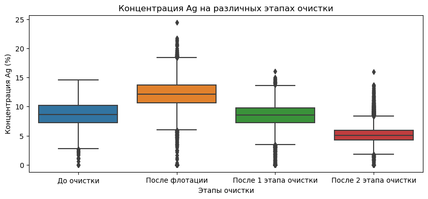

```
Данные по металлу Pb
```

|  | До очистки | После флотации | После 1 этапа очистки | После 2 этапа очистки |
| --- | --- | --- | --- | --- |
| 0 | 2.284912 | 7.101074 | 10.389648 | 9.889648 |
| 1 | 2.266033 | 7.278807 | 10.497069 | 9.968944 |
| 2 | 2.159622 | 7.216833 | 10.354494 | 10.213995 |
| 3 | 2.037807 | 7.175616 | 8.496563 | 9.977019 |
| 4 | 1.786875 | 7.240205 | 9.986786 | 10.142511 |

```
         До очистки  После флотации  После 1 этапа очистки  \
count  19339.000000    19439.000000           19323.000000
mean       3.598085        7.606272               9.829530
std        1.049486        1.796757               2.556843
min        0.010000        0.000000               0.000000
25%        2.887280        6.725987               8.702328
50%        3.534895        7.742580              10.152433
75%        4.244161        8.565199              11.424971
max        7.142594       13.617072              17.081278

       После 2 этапа очистки
count           19438.000000
mean                9.978895
std                 1.669240
min                 0.000000
25%                 9.137262
50%                10.102433
75%                11.035769
max                17.031899
```

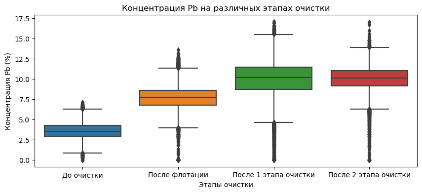

```python
metal_concentration(data[2])
```

### Сравним распределение размеров гранул сырья на обучающей и тестовой выборках

```python
# напишем функцию для сравнения любых параметров в тестовой и тренировочной выборках
def compare_train_test(train_data, test_data, features):
    for i in features:
        tempt_table = pd.DataFrame()
        tempt_table[i + '_train'] = train_data[i]
        tempt_table[i + '_test'] = test_data[i]
        print(tempt_table.describe())
        #сравним боксплоты
        plt.figure(figsize=(8, 4))
        sns.boxplot(data=tempt_table)
        plt.xlabel('Выборка')
        plt.ylabel(f'Величина показателя')
        plt.title(f'Сравнение показателя {i} в тестовой и тренировочной выборках')
        plt.show()
        #проверим статистическую значимость различий.
        #гипотеза Н0 - медианы данных выборок равны, Н1 - медианы разные.
        alpha = 0.05
        result = st.ttest_ind(tempt_table[i + '_train'], tempt_table[i + '_test'], equal_var=False)
        if result.pvalue < alpha:
            print('Показатели в тестовой и тренировочной выборке имеют статистически значимые различия, могут возникнуть проблемы при построении моделей!')
        else:
            print('Показатели в тестовой и тренировочной выборке не имеют статистически значимых различий!')
        print()
```

```
       rougher.input.feed_size_train  rougher.input.feed_size_test
count                   14149.000000                   5290.000000
mean                       60.110671                     55.948764
std                        22.458576                     19.080708
min                         9.659576                      0.046369
25%                        48.986485                     43.905687
50%                        55.278338                     50.834264
75%                        65.996388                     62.425276
max                       484.967466                    392.494040
```

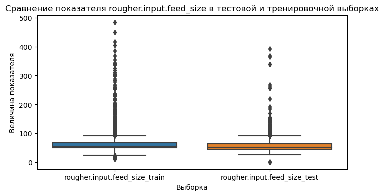

```
Показатели в тестовой и тренировочной выборке не имеют статистически значимых различий!

       primary_cleaner.input.feed_size_train  \
count                           14149.000000
mean                                7.322310
std                                 0.614062
min                                 1.080000
25%                                 6.960000
50%                                 7.290000
75%                                 7.700000
max                                10.470000

       primary_cleaner.input.feed_size_test
count                           5290.000000
mean                               7.266339
std                                0.610219
min                                5.650000
25%                                6.890000
50%                                7.250000
75%                                7.600000
max                               15.500000
```

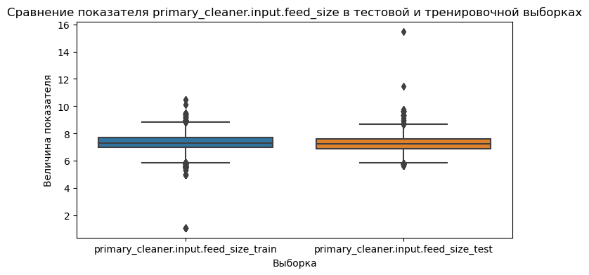

```
Показатели в тестовой и тренировочной выборке не имеют статистически значимых различий!
```

```python
compare_train_test(data[0], data[1], ['rougher.input.feed_size', 'primary_cleaner.input.feed_size'])
```

### Исследуем суммарную концентрацию всех веществ на разных стадиях:

- в сырье,
- в черновом концентрате
- в финальном концентрате.

#### Содержание веществ в сырье

```python
#напишем функцию для рассчета концентрации веществ на определенном этапе
def total_concentration(data, stage):
    table = data[[stage + '_au', stage + '_ag', stage + '_pb', stage + '_sol']]
    table[stage + '_other'] = 100 - table.iloc[:, 0:4].sum(axis=1) #обозначим оставшуюся часть как 'other'
    display(table.head())
    # построим боксплот
    plt.figure(figsize=(15, 5))
    sns.boxplot(data=table)
    plt.xlabel('Вещество')
    plt.ylabel('Концентрация')
    plt.title('Распределение концентрации различных веществ')
    plt.show()
    #построим пайплот средних концентраций веществ.
    percent = list(table.iloc[:, 0:4].mean())
    percent.append(100 - sum(percent))
    plt.pie(percent,
            labels=table.columns,
            labeldistance=1.15,
            wedgeprops = { 'linewidth' : 3, 'edgecolor' : 'white' },
            autopct='%.1f')
    plt.title('Средняя концентрации различных веществ в руде')
    plt.show()
```

|  | rougher.input.feed_au | rougher.input.feed_ag | rougher.input.feed_pb | rougher.input.feed_sol | rougher.input.feed_other |
| --- | --- | --- | --- | --- | --- |
| 0 | 6.486150 | 6.100378 | 2.284912 | 36.808594 | 48.319966 |
| 1 | 6.478583 | 6.161113 | 2.266033 | 35.753385 | 49.340886 |
| 2 | 6.362222 | 6.116455 | 2.159622 | 35.971630 | 49.390071 |
| 3 | 6.118189 | 6.043309 | 2.037807 | 36.862241 | 48.938454 |
| 4 | 5.663707 | 6.060915 | 1.786875 | 34.347666 | 52.140837 |

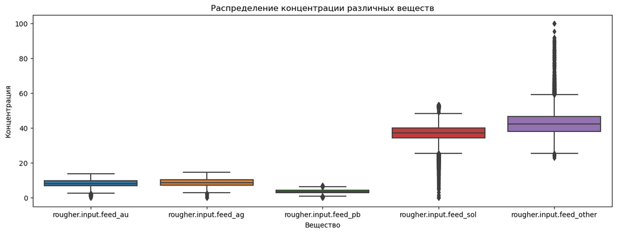

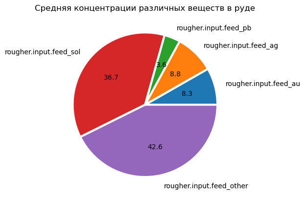

```python
total_concentration(data[2], 'rougher.input.feed')
```

В первичном сырье отмечается достаточно низкое содержание металлов **Au**, **Ag**, **Pb**. Большую часть первичного сырья составляет вещество **sol** и прочие примеси (**other**) - практически по **40%**.

#### Содержание веществ в черновом концентрате

|  | rougher.output.concentrate_au | rougher.output.concentrate_ag | rougher.output.concentrate_pb | rougher.output.concentrate_sol | rougher.output.concentrate_other |
| --- | --- | --- | --- | --- | --- |
| 0 | 19.793808 | 11.500771 | 7.101074 | 28.029297 | 33.575050 |
| 1 | 20.050975 | 11.615865 | 7.278807 | 28.067063 | 32.987290 |
| 2 | 19.737170 | 11.695753 | 7.216833 | 27.454037 | 33.896207 |
| 3 | 19.320810 | 11.915047 | 7.175616 | 27.341277 | 34.247249 |
| 4 | 19.216101 | 12.411054 | 7.240205 | 27.041023 | 34.091618 |

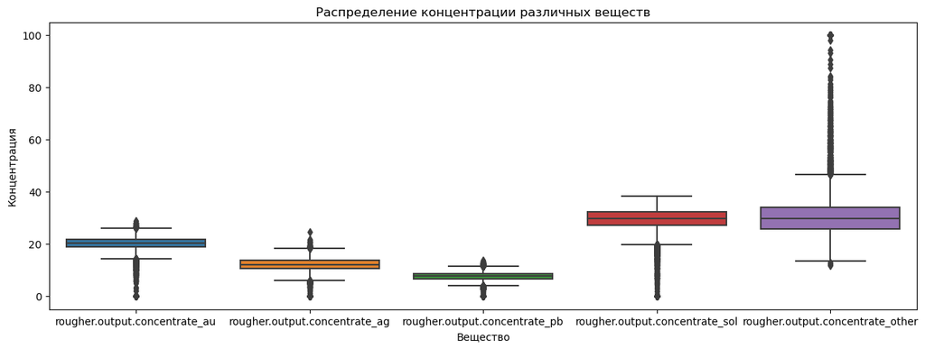

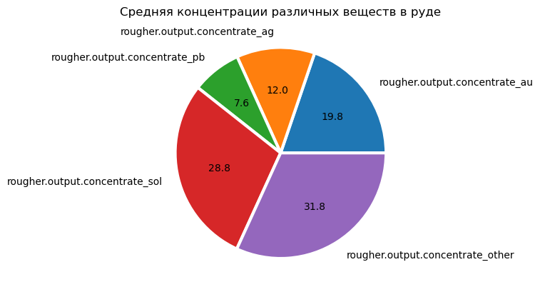

```python
total_concentration(data[2], 'rougher.output.concentrate')
```

Вчерновом концентрате увеличивается содержание **Au** (до **19.8%**). Концентрация вещества **sol** и веществ **other** снижается до **30%**.

#### Содержание веществ в финальном концентрате

|  | final.output.concentrate_au | final.output.concentrate_ag | final.output.concentrate_pb | final.output.concentrate_sol | final.output.concentrate_other |
| --- | --- | --- | --- | --- | --- |
| 0 | 42.192020 | 6.055403 | 9.889648 | 5.507324 | 36.355604 |
| 1 | 42.701629 | 6.029369 | 9.968944 | 5.257781 | 36.042277 |
| 2 | 42.657501 | 6.055926 | 10.213995 | 5.383759 | 35.688820 |
| 3 | 42.689819 | 6.047977 | 9.977019 | 4.858634 | 36.426551 |
| 4 | 42.774141 | 6.148599 | 10.142511 | 4.939416 | 35.995333 |

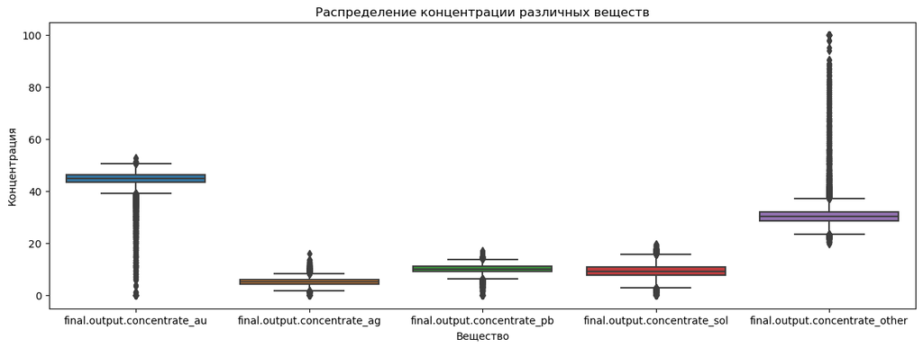

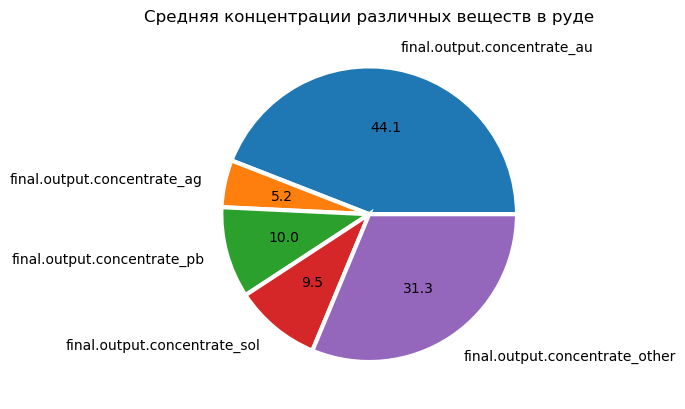

```python
total_concentration(data[2], 'final.output.concentrate')
```

В финальном концентрате большую часть объема составляет Au - 44%. Значительно падает концентрация вещества sol, содержание прочих веществ (other ) составляет 31%.

Исходя из графиков распределения концетрации различных веществ видно, что некоторые значения являются выбросами. Вряд ли существует руда, в которой нулевая концентрация всех элементов. Избавимся от наиболее вероятного выброса в тренировочной выборке, где сумма концентраций всех веществ в концентратах равна 0.

```python
stage = ['final.output.concentrate', 'rougher.output.concentrate', 'rougher.input.feed']
for j in stage:
    a = data[2][data[2][[j + '_au', j + '_ag', j + '_pb', j + '_sol']].sum(axis=1) == 0]
    for i in a.index:
        if i in data[0].index:
            data[0].drop(index=i, axis=1, inplace=True)
        else:
            pass
    data[0].info()
data[0]
```

```
<class 'pandas.core.frame.DataFrame'>
Int64Index: 14070 entries, 0 to 14148
Data columns (total 55 columns):
 #   Column                                      Non-Null Count  Dtype
---  ------                                      --------------  -----
 0   date                                        14070 non-null  datetime64[ns]
 1   final.output.recovery                       14070 non-null  float64
 2   primary_cleaner.input.sulfate               14070 non-null  float64
 3   primary_cleaner.input.depressant            14070 non-null  float64
 4   primary_cleaner.input.feed_size             14070 non-null  float64
 5   primary_cleaner.input.xanthate              14070 non-null  float64
 6   primary_cleaner.state.floatbank8_a_air      14070 non-null  float64
 7   primary_cleaner.state.floatbank8_a_level    14070 non-null  float64
 8   primary_cleaner.state.floatbank8_b_air      14070 non-null  float64
 9   primary_cleaner.state.floatbank8_b_level    14070 non-null  float64
```

[output cut: 171 more lines]

|  | date | final.output.recovery | primary_cleaner.input.sulfate | primary_cleaner.input.depressant | primary_cleaner.input.feed_size | primary_cleaner.input.xanthate | primary_cleaner.state.floatbank8_a_air | primary_cleaner.state.floatbank8_a_level | primary_cleaner.state.floatbank8_b_air | primary_cleaner.state.floatbank8_b_level | ... | secondary_cleaner.state.floatbank4_a_air | secondary_cleaner.state.floatbank4_a_level | secondary_cleaner.state.floatbank4_b_air | secondary_cleaner.state.floatbank4_b_level | secondary_cleaner.state.floatbank5_a_air | secondary_cleaner.state.floatbank5_a_level | secondary_cleaner.state.floatbank5_b_air | secondary_cleaner.state.floatbank5_b_level | secondary_cleaner.state.floatbank6_a_air | secondary_cleaner.state.floatbank6_a_level |
| --- | --- | --- | --- | --- | --- | --- | --- | --- | --- | --- | --- | --- | --- | --- | --- | --- | --- | --- | --- | --- | --- |
| 0 | 2016-01-15 00:00:00 | 70.541216 | 127.092003 | 10.128295 | 7.25 | 0.988759 | 1549.775757 | -498.912140 | 1551.434204 | -516.403442 | ... | 14.016835 | -502.488007 | 12.099931 | -504.715942 | 9.925633 | -498.310211 | 8.079666 | -500.470978 | 14.151341 | -605.841980 |
| 1 | 2016-01-15 01:00:00 | 69.266198 | 125.629232 | 10.296251 | 7.25 | 1.002663 | 1576.166671 | -500.904965 | 1575.950626 | -499.865889 | ... | 13.992281 | -505.503262 | 11.950531 | -501.331529 | 10.039245 | -500.169983 | 7.984757 | -500.582168 | 13.998353 | -599.787184 |
| 2 | 2016-01-15 02:00:00 | 68.116445 | 123.819808 | 11.316280 | 7.25 | 0.991265 | 1601.556163 | -499.997791 | 1600.386685 | -500.607762 | ... | 14.015015 | -502.520901 | 11.912783 | -501.133383 | 10.070913 | -500.129135 | 8.013877 | -500.517572 | 14.028663 | -601.427363 |
| 3 | 2016-01-15 03:00:00 | 68.347543 | 122.270188 | 11.322140 | 7.25 | 0.996739 | 1599.968720 | -500.951778 | 1600.659236 | -499.677094 | ... | 14.036510 | -500.857308 | 11.999550 | -501.193686 | 9.970366 | -499.201640 | 7.977324 | -500.255908 | 14.005551 | -599.996129 |
| 4 | 2016-01-15 04:00:00 | 66.927016 | 117.988169 | 11.913613 | 7.25 | 1.009869 | 1601.339707 | -498.975456 | 1601.437854 | -500.323246 | ... | 14.027298 | -499.838632 | 11.953070 | -501.053894 | 9.925709 | -501.686727 | 7.894242 | -500.356035 | 13.996647 | -601.496691 |
| ... | ... | ... | ... | ... | ... | ... | ... | ... | ... | ... | ... | ... | ... | ... | ... | ... | ... | ... | ... | ... | ... |
| 14144 | 2018-08-18 06:59:59 | 73.755150 | 123.381787 | 8.028927 | 6.50 | 1.304232 | 1648.421193 | -400.382169 | 1648.742005 | -400.359661 | ... | 23.031497 | -501.167942 | 20.007571 | -499.740028 | 18.006038 | -499.834374 | 13.001114 | -500.155694 | 20.007840 | -501.296428 |
| 14145 | 2018-08-18 07:59:59 | 69.049291 | 120.878188 | 7.962636 | 6.50 | 1.302419 | 1649.820162 | -399.930973 | 1649.357538 | -399.721222 | ... | 22.960095 | -501.612783 | 20.035660 | -500.251357 | 17.998535 | -500.395178 | 12.954048 | -499.895163 | 19.968498 | -501.041608 |
| 14146 | 2018-08-18 08:59:59 | 67.002189 | 105.666118 | 7.955111 | 6.50 | 1.315926 | 1649.166761 | -399.888631 | 1649.196904 | -399.677571 | ... | 23.015718 | -501.711599 | 19.951231 | -499.857027 | 18.019543 | -500.451156 | 13.023431 | -499.914391 | 19.990885 | -501.518452 |
| 14147 | 2018-08-18 09:59:59 | 65.523246 | 98.880538 | 7.984164 | 6.50 | 1.241969 | 1646.547763 | -398.977083 | 1648.212240 | -400.383265 | ... | 23.024963 | -501.153409 | 20.054122 | -500.314711 | 17.979515 | -499.272871 | 12.992404 | -499.976268 | 20.013986 | -500.625471 |
| 14148 | 2018-08-18 10:59:59 | 70.281454 | 95.248427 | 8.078957 | 6.50 | 1.283045 | 1648.759906 | -399.862053 | 1650.135395 | -399.957321 | ... | 23.018622 | -500.492702 | 20.020205 | -500.220296 | 17.963512 | -499.939490 | 12.990306 | -500.080993 | 19.990336 | -499.191575 |

13802 rows × 55 columns

Так же нам для формулы расчета **recovery** необходимы значения данного показателя на различных этапах. Значение показателя равное нулю очень похоже на выброс. Удалим строки, где значение показателя равно 0.

```python
data[0].drop(index=data[0][data[0]['final.output.recovery'] == 0].index, axis=1, inplace=True)
data[0].drop(index=data[0][data[0]['rougher.output.recovery'] == 0].index, axis=1, inplace=True)
data[0].info()
```

```
<class 'pandas.core.frame.DataFrame'>
Int64Index: 13496 entries, 0 to 14148
Data columns (total 55 columns):
 #   Column                                      Non-Null Count  Dtype
---  ------                                      --------------  -----
 0   date                                        13496 non-null  datetime64[ns]
 1   final.output.recovery                       13496 non-null  float64
 2   primary_cleaner.input.sulfate               13496 non-null  float64
 3   primary_cleaner.input.depressant            13496 non-null  float64
 4   primary_cleaner.input.feed_size             13496 non-null  float64
 5   primary_cleaner.input.xanthate              13496 non-null  float64
 6   primary_cleaner.state.floatbank8_a_air      13496 non-null  float64
 7   primary_cleaner.state.floatbank8_a_level    13496 non-null  float64
 8   primary_cleaner.state.floatbank8_b_air      13496 non-null  float64
 9   primary_cleaner.state.floatbank8_b_level    13496 non-null  float64
```

[output cut: 47 more lines]

**В целом можно отметить, что технологический процесс ,направленный на обогащение руды золотом, работает правильно, концентрация золота увеличивается на каждом этапе очистки. Оценим эффективность данного процесса.**

## Модель

### Напишем функцию для вычисления итоговой sMAPE.

```python
#функция для расчета итоговой sMAPE на тестовой выборке
def smape_calc_for_test(final, final_predict, rougher, rougher_predict):
    smape_final = 100 / len(final) * sum(2 * abs(final - final_predict) /
                                        (abs(final) + abs(final_predict)))
    smape_rougher = 100 / len(rougher) * sum(2 * abs(rougher - rougher_predict) /
                                        (abs(rougher) + abs(rougher_predict)))
    result = 0.25 * smape_rougher + 0.75 * smape_final
    print(f'Итоговая sMAPE равна {result:0.2f}%')
```

```python
#функция для расчета sMAPE для отдельных признаков.
def smape_calc(feature, predict):
    smape = 100 / len(feature) * sum(2 * abs(feature - predict) /
                                        (abs(feature) + abs(predict)))
    return smape
```

```python
# функция для расчета итоговой sMAPE
def final_smape_calc(smape_rough, smape_fin):
    result = 0.25 * smape_rough + 0.75 * smape_fin
    return result
```

### Подготовка к моделированию

```python
# функция для масштабирования признаков
def scaler_transform(data_train, data_test):
    scaler = StandardScaler()
    X_train = scaler.fit_transform(data_train)
    X_test = scaler.transform(data_test)
    return X_train, X_test
```

```python
# функция для разделения тренировочной и тестовой выборок на таргет и фичи, с масштабированием значений фичей
def make_feature_target(data_train, data_test):
    X_train = data_train.drop(['date', 'final.output.recovery', 'rougher.output.recovery'], axis=1)
    y_train_final = data_train['final.output.recovery']
    y_train_rougher = data_train['rougher.output.recovery']
    X_test = data_test.drop(['date', 'final.output.recovery', 'rougher.output.recovery'], axis=1)
    y_test_final = data_test['final.output.recovery']
    y_test_rougher = data_test['rougher.output.recovery']
    X_train, X_test = scaler_transform(X_train, X_test)
    return X_train, y_train_final, y_train_rougher, X_test, y_test_final, y_test_rougher
```

```python
final_data = make_feature_target(data[0], data[1])
```

```python
#создадим новый scorer для выбора лучшей модели при проведении кроссвалидации
smape_scorer = make_scorer(smape_calc, greater_is_better=False)
```

### Обучение модели.

Обучим молель **DecisionTree**, **RandomForest** и **LinearRegression**.

#### Decision Tree

```python
#функция для поиска лучшей модели дерево решений
def best_model_dtr(X_train, y_train_final, y_train_rougher):
    model = DecisionTreeRegressor(random_state=STATE)
    params = {'max_depth':range(1,10),
              'min_samples_split':range(2,5),
              'min_samples_leaf':range(1,5)}
    grid_model_final = RandomizedSearchCV(model,
                                          params,
                                          cv=5,
                                          scoring=smape_scorer,
                                          error_score='raise',
                                          n_jobs=-1,
                                          verbose=1)
    grid_model_final.fit(X_train, y_train_final)
    grid_model_rougher = RandomizedSearchCV(model,
                                            params,
                                            cv=5,
                                            scoring=smape_scorer,
                                            error_score='raise',
                                            n_jobs=-1,
                                            verbose=1)
    grid_model_rougher.fit(X_train, y_train_rougher)
    print('Значение sMAPE у лучшей модели, прогнозирующей final.output.recovery = ', grid_model_final.best_score_)
    print('Лучшие параметры модели:', grid_model_final.best_params_)
    print('Значение sMAPE у лучшей модели, прогнозирующей rougher.output.recovery = ', grid_model_rougher.best_score_)
    print('Лучшие параметры модели:', grid_model_rougher.best_params_)
    print('Итоговое значение sMAPE равно ', final_smape_calc(grid_model_rougher.best_score_, grid_model_final.best_score_))
    return grid_model_final, grid_model_rougher
```

```python
dtr_model_final, dtr_model_rougher = best_model_dtr(final_data[0], final_data[1], final_data[2])
```

```
Fitting 5 folds for each of 10 candidates, totalling 50 fits
Fitting 5 folds for each of 10 candidates, totalling 50 fits
Значение sMAPE у лучшей модели, прогнозирующей final.output.recovery =  -9.718946552358554
Лучшие параметры модели: {'min_samples_split': 2, 'min_samples_leaf': 2, 'max_depth': 3}
Значение sMAPE у лучшей модели, прогнозирующей rougher.output.recovery =  -6.8472648141274375
Лучшие параметры модели: {'min_samples_split': 2, 'min_samples_leaf': 1, 'max_depth': 3}
Итоговое значение sMAPE равно  -9.001026117800775
```

#### Random Forest

```python
# Для начала найдем лучшие параметры модели на небольшом количестве деревьев
#с целью экономии времени обучения, а в целом можно и нужно количество деревьев сразу смотреть.
# Затем подберем такой гиперпараметр как количество деревьев
def best_model_rfr(X_train, y_train_final, y_train_rougher):
    model = RandomForestRegressor(random_state=STATE, n_estimators=20)
    params = {'max_depth':range(1,10), 'min_samples_split':range(2,5), 'min_samples_leaf':range(1,5)}
    grid_model_final = RandomizedSearchCV(model,
                                          params,
                                          cv=5,
                                          scoring='neg_mean_absolute_error',
                                          refit='neg_mean_absolute_error',
                                          error_score='raise',
                                          n_jobs=-1,
                                          verbose=1,
                                          random_state=STATE)
    grid_model_final.fit(X_train, y_train_final)
    grid_model_rougher = RandomizedSearchCV(model,
                                            params,
                                            cv=5,
                                            scoring='neg_mean_absolute_error',
                                            refit='neg_mean_absolute_error',
                                            error_score='raise',
                                            n_jobs=-1,
                                            verbose=1,
                                            random_state=STATE)
    grid_model_rougher.fit(X_train, y_train_rougher)
    model = RandomForestRegressor(random_state=STATE)
    params_final = {'n_estimators':range(20,200,10),
                    'max_depth':[grid_model_final.best_params_['max_depth']],
                    'min_samples_split':[grid_model_final.best_params_['min_samples_split']],
                    'min_samples_leaf':[grid_model_final.best_params_['min_samples_leaf']]}
    params_rougher = {'n_estimators':range(20,200,10),
                      'max_depth':[grid_model_rougher.best_params_['max_depth']],
                      'min_samples_split':[grid_model_rougher.best_params_['min_samples_split']],
                      'min_samples_leaf':[grid_model_rougher.best_params_['min_samples_leaf']]}
    grid_model_final = RandomizedSearchCV(model,
                                          params_final,
                                          cv=5,
                                          scoring=smape_scorer,
                                          error_score='raise',
                                          n_jobs=-1,
                                          verbose=1,
                                          random_state=STATE)
    grid_model_final.fit(X_train, y_train_final)
    grid_model_rougher = RandomizedSearchCV(model,
                                            params_rougher,
                                            cv=5,
                                            scoring=smape_scorer,
                                            error_score='raise',
                                            n_jobs=-1,
                                            verbose=1,
                                            random_state=STATE)
    grid_model_rougher.fit(X_train, y_train_rougher)
    print('Значение sMAPE у лучшей модели, прогнозирующей final.output.recovery = ', grid_model_final.best_score_)
    print('Лучшие параметры модели:', grid_model_final.best_params_)
    print('Значение sMAPE у лучшей модели, прогнозирующей rougher.output.recovery = ', grid_model_rougher.best_score_)
    print('Лучшие параметры модели:', grid_model_rougher.best_params_)
    print('Итоговое значение sMAPE равно ', final_smape_calc(grid_model_rougher.best_score_, grid_model_final.best_score_))
    return grid_model_final, grid_model_rougher
```

```python
rfr_model_final, rfr_model_rougher = best_model_rfr(final_data[0], final_data[1], final_data[2])
```

```
Fitting 5 folds for each of 10 candidates, totalling 50 fits
Fitting 5 folds for each of 10 candidates, totalling 50 fits
Fitting 5 folds for each of 10 candidates, totalling 50 fits
Fitting 5 folds for each of 10 candidates, totalling 50 fits
Значение sMAPE у лучшей модели, прогнозирующей final.output.recovery =  -9.088381005251476
Лучшие параметры модели: {'n_estimators': 60, 'min_samples_split': 4, 'min_samples_leaf': 1, 'max_depth': 4}
Значение sMAPE у лучшей модели, прогнозирующей rougher.output.recovery =  -6.219747538050041
Лучшие параметры модели: {'n_estimators': 60, 'min_samples_split': 4, 'min_samples_leaf': 1, 'max_depth': 6}
Итоговое значение sMAPE равно  -8.371222638451117
```

#### Linear Regression

```python
# функция для поиска лучшей модели линейной регрессии
def best_model_lr(X_train, y_train_final, y_train_rougher):
    model = LinearRegression()
    params = {}
    grid_model_final = RandomizedSearchCV(model,
                                          params,
                                          cv=5,
                                          scoring=smape_scorer,
                                          error_score='raise',
                                          n_jobs=-1,
                                          verbose=1,
                                          random_state=STATE)
    grid_model_final.fit(X_train, y_train_final)
    grid_model_rougher = RandomizedSearchCV(model,
                                            params,
                                            cv=5,
                                            scoring=smape_scorer,
                                            error_score='raise',
                                            n_jobs=-1,
                                            verbose=1,
                                            random_state=STATE)
    grid_model_rougher.fit(X_train, y_train_rougher)
    print('Значение sMAPE у лучшей модели, прогнозирующей final.output.recovery = ', grid_model_final.best_score_)
    print('Значение sMAPE у лучшей модели, прогнозирующей rougher.output.recovery = ', grid_model_rougher.best_score_)
    print('Итоговое значение sMAPE равно ', final_smape_calc(grid_model_rougher.best_score_, grid_model_final.best_score_))
    return grid_model_final, grid_model_rougher
```

```python
lr_model_final, lr_model_rougher = best_model_lr(final_data[0], final_data[1], final_data[2])
```

```
Fitting 5 folds for each of 1 candidates, totalling 5 fits
Fitting 5 folds for each of 1 candidates, totalling 5 fits
Значение sMAPE у лучшей модели, прогнозирующей final.output.recovery =  -11.71976618939571
Значение sMAPE у лучшей модели, прогнозирующей rougher.output.recovery =  -7.032295982060387
Итоговое значение sMAPE равно  -10.547898637561879
```

#### LGBMRegressor

```python
# функция для поиска лучшей модели LGBMRegressor
def best_model_lgbm(X_train, y_train_final, y_train_rougher):
    model = LGBMRegressor(random_state=STATE)
    params = {'learning_rate':(0.001, 0.01, 0.1, 0.2, 0.3, 0.4, 0.5, 0.6, 0.7, 0.8, 0.9),
              'n_estimators':range(20, 200, 20),
              'max_depth':range(1,15),
              'min_data_in_leaf':range(1,40)}
    grid_model_final = RandomizedSearchCV(model,
                                          params,
                                          cv=5,
                                          scoring=smape_scorer,
                                          error_score='raise',
                                          n_jobs=-1,
                                          verbose=1,
                                          random_state=STATE)
    grid_model_final.fit(X_train, y_train_final)
    grid_model_rougher = RandomizedSearchCV(model,
                                            params,
                                            cv=5,
                                            scoring=smape_scorer,
                                            error_score='raise',
                                            n_jobs=-1,
                                            verbose=1,
                                            random_state=STATE)
    grid_model_rougher.fit(X_train, y_train_rougher)
    print('Значение sMAPE у лучшей модели, прогнозирующей final.output.recovery = ', grid_model_final.best_score_)
    print('Значение sMAPE у лучшей модели, прогнозирующей rougher.output.recovery = ', grid_model_rougher.best_score_)
    print('Итоговое значение sMAPE равно ', final_smape_calc(grid_model_rougher.best_score_, grid_model_final.best_score_))
    return grid_model_final, grid_model_rougher
```

```python
lgbm_model_final, lgbm_model_rougher = best_model_lgbm(final_data[0], final_data[1], final_data[2])
```

```
Fitting 5 folds for each of 10 candidates, totalling 50 fits
[LightGBM] [Warning] min_data_in_leaf is set=5, min_child_samples=20 will be ignored. Current value: min_data_in_leaf=5
Fitting 5 folds for each of 10 candidates, totalling 50 fits
Значение sMAPE у лучшей модели, прогнозирующей final.output.recovery =  -9.24557155141584
Значение sMAPE у лучшей модели, прогнозирующей rougher.output.recovery =  -6.030732741462608
Итоговое значение sMAPE равно  -8.441861848927532
```

Лучшей моделью для рассчета итоговой sMAPE по итогам проведенного исследования оказалась модель **Random Forest**. Итоговое значение sMAPE на тренировочной выборке было равно **8.37%**. Именно данную модель решено использовать для работы с тестовой выборкой.

```python
rfr_fin = rfr_model_final.predict(final_data[3])
rfr_rough = rfr_model_rougher.predict(final_data[3])
smape_calc_for_test(final_data[4], rfr_fin, final_data[5], rfr_rough)
```

```
Итоговая sMAPE равна 9.23%
```

```python
dummy_model = DummyRegressor()
# предскажем final.recovery
dummy_model.fit(final_data[0], final_data[1])
dummy_predict_final = dummy_model.predict(final_data[3])
# предскажем rougher.recovery
dummy_model.fit(final_data[0], final_data[2])
dummy_predict_rougher = dummy_model.predict(final_data[3])
#найдем итоговую sMAPE
smape_calc_for_test(final_data[4], dummy_predict_final, final_data[5], dummy_predict_rougher)
```

```
Итоговая sMAPE равна 9.88%
```

## Выводы

Перед нами стояла задача предсказания коэффициента восстановления золота из золотосодержащей руды. Были предоставлены 3 датасета с данными, которые нам необходимо было обработать для дальнейшей работы. В ходе работы нами выпонено:

- загрузили данные и ознакомились с датасетами.
  - в датасете `gold_recovery_train_new` представлено 87 признаков, описывающих процесс восстановления золота из руды. Столбец **data** имеет тип данных **object**, нужно заменить на **datetime**. В некоторых столбцах присутсвуют пропуски. Попробуем заполнить их данными из датасета `gold_recovery_full_new`, если пропуски останутся заполним их медианными значениями.
  - в датасете `gold_recovery_test_new` представлено 53 признака, причем нет целевых признаков, необходимых для расчета **SMAPE**, это **rougher.output.recovery** и **final.output.recovery**. В столбце **date** также изменим тип данных. Пропуски постараемся заполнить аналогичным образом. В некоторых столбцах присутсвуют пропуски. Попробуем заполнить их данными из датасета `gold_recovery_full_new`, если пропуски останутся заполним их медианными значениями.
  - в датасете `gold_recovery_full_new` представлено также 87 признаков. В столбце **date** изменим тип данных.
- проверили правильность расчета эффективности обогащения (эффективность обогащения рассчитана правильно, MAE приближается к 0).
- проанализировали признаки, недоступные в тестовой выборке
  - В тестовой выборке недоступны признаки, которые рассчитываются в процессе восстановления золота из руды. Это концентрации различных примесей до определенного этапа обработки, после данного этапа, их соотношения, тип всех данных **float**.
  - В процессе прогнозировнаия для нас будут доступны только показатели из тестовой выборки, поэтому при создании моделей будем использовать только указанные показатели. Из обучающего датасета удалили недоступные в тестовой выборке признаки.
- провели предобработку данных (заполнили пропуски, добавили целевый признаки, преобразовали столбец с датой)
- оценили, как меняется концентрация металлов (Au, Ag, Pb) на различных этапах очистки
- сравнили распределение размеров гранул сырья на обучающей и тестовой выборках (с примененим статистических тестов)
- исследовали суммарную концентрацию всех веществ в сырье, в черновом концентрате, в финальном концентрате. На основе данного этапа избавились от выборосов в данных.
- при моделировании обучили модели **DecisionTree**, **RandomForest** и **LinearRegression** с применением метода кросвалидации.

**Лучшей моделью для рассчета итоговой sMAPE по итогам проведенного исследования оказалась модель Random Forest. Итоговое значение sMAPE на тренировочной выборке было равно 8.37%. Именно данную модель решено использовать для работы с тестовой выборкой.**

**Постоенная нами модель Random Forest показала достаточно высокую эффективность на тестовых данных, итоговая sMAPE равна 9.23%.**  
**Данная модель рекомендовала раказчику для примения на производстве.**